# Section 2: Data Visualization (Part 1)

MTH 365: Introduction to Data Science

September 09, 2020

## Recommended Reading

- *Modern Data Science with R* Ch. 2: Data Visualization
- *Modern Data Science with R* Ch. 3: A Grammar for Graphics

```r
#install.packages(dslabs)
library(dslabs)
```

## `ggplot2`

`ggplot2` is an R package for “declaratively creating graphics”

- https://ggplot2.tidyverse.org/reference/

**Basic Format of a Plot**:

`data and aesthetics + plot type + options`

```r
#install.packages(tidyverse)
library(tidyverse)
library(ggplot2)
```

## Example: Hate crimes and income inequality

A FiveThirtyEight article published in 2017 claimed that higher rates of hate crimes were tied to greater income inequality.

https://fivethirtyeight.com/features/higher-rates-of-hate-crimes-are-tied-to-income-inequality/

- FiveThirtyEight publishes their data sets - let’s investigate for ourselves.
- Data sets are posted on BlueLine. Download this data set, and save it to your computer.

Follow these steps to read the data into RStudio:

1. In the Environment tab, click “Import Dataset”. Since this is a CSV document, you want to import a text file.
2. Navigate to your CSV data set. Make sure that the first row contains column names.
3. Import the data.

You’ll see a line of code pop up in your R console, it should start with `read.csv()`. Copy this code and replace the provided statement (`hate_crimes <- read.csv("~/OneDrive - Creighton University/Spring 2019 Courses/MTH 365 - Intro to Data Science/Data/hate_crimes.csv")`) with the one you just generated.

```r
library(readr)
hate_crimes <- read_csv("C:/Users/vivia/Downloads/hate_crimes.csv")
View(hate_crimes)
glimpse(hate_crimes)
```

```
## Rows: 51
## Columns: 13
## $ state            <chr> "Alabama", "Alaska", "Arizona", "Arkansas", "Calif...
## $ region           <chr> "South", "West", "West", "South", "West", "West", ...
## $ median_income    <dbl> 42278, 67629, 49254, 44922, 60487, 60940, 70161, 5...
## $ unemployment     <dbl> 0.060, 0.064, 0.063, 0.052, 0.059, 0.040, 0.052, 0...
## $ metro            <dbl> 0.64, 0.63, 0.90, 0.69, 0.97, 0.80, 0.94, 0.90, 1....
## $ hs_degree        <dbl> 0.821, 0.914, 0.842, 0.824, 0.806, 0.893, 0.886, 0...
## $ non_citizen      <dbl> 0.02, 0.04, 0.10, 0.04, 0.13, 0.06, 0.06, 0.05, 0....
## $ white_poverty    <dbl> 0.12, 0.06, 0.09, 0.12, 0.09, 0.07, 0.06, 0.08, 0....
## $ gini_index       <dbl> 0.472, 0.422, 0.455, 0.458, 0.471, 0.457, 0.486, 0...
## $ non_white        <dbl> 0.35, 0.42, 0.49, 0.26, 0.61, 0.31, 0.30, 0.37, 0....
## $ trump_vote       <dbl> 0.63, 0.53, 0.50, 0.60, 0.33, 0.44, 0.41, 0.42, 0....
## $ hate_crimes_splc <dbl> 0.12583893, 0.14374012, 0.22531995, 0.06906077, 0....
## $ hate_crimes_fbi  <dbl> 1.8064105, 1.6567001, 3.4139280, 0.8692089, 2.3979...
```

## A simple plot?

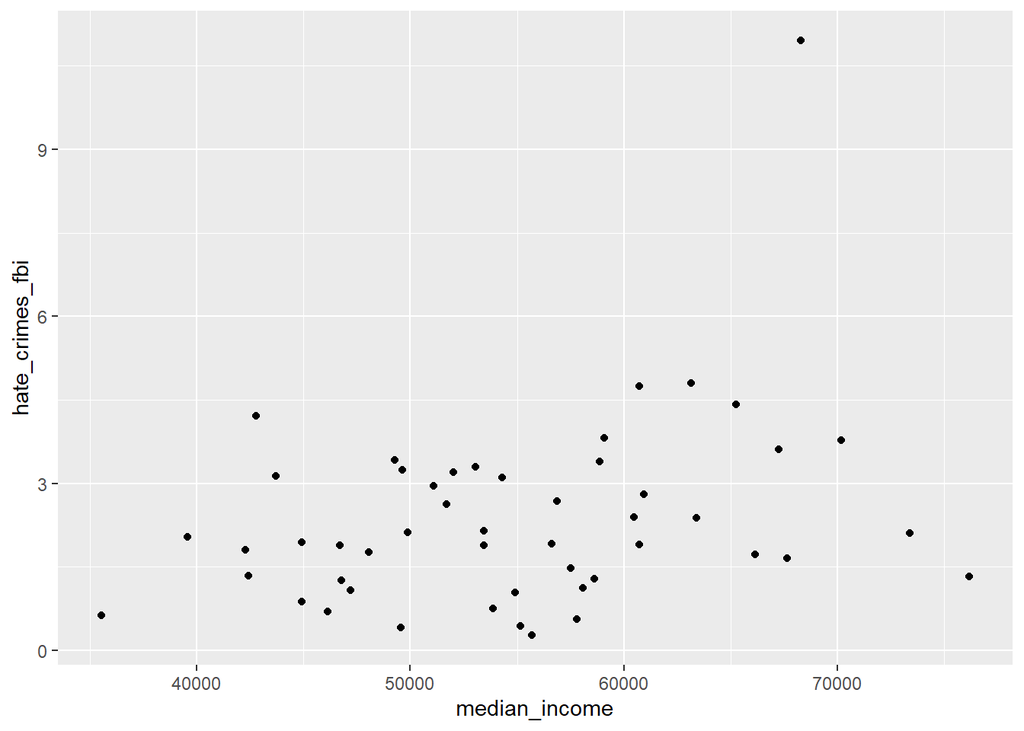

```r
ggplot(hate_crimes, aes(x=median_income, y=hate_crimes_fbi)) +
  geom_point()
```

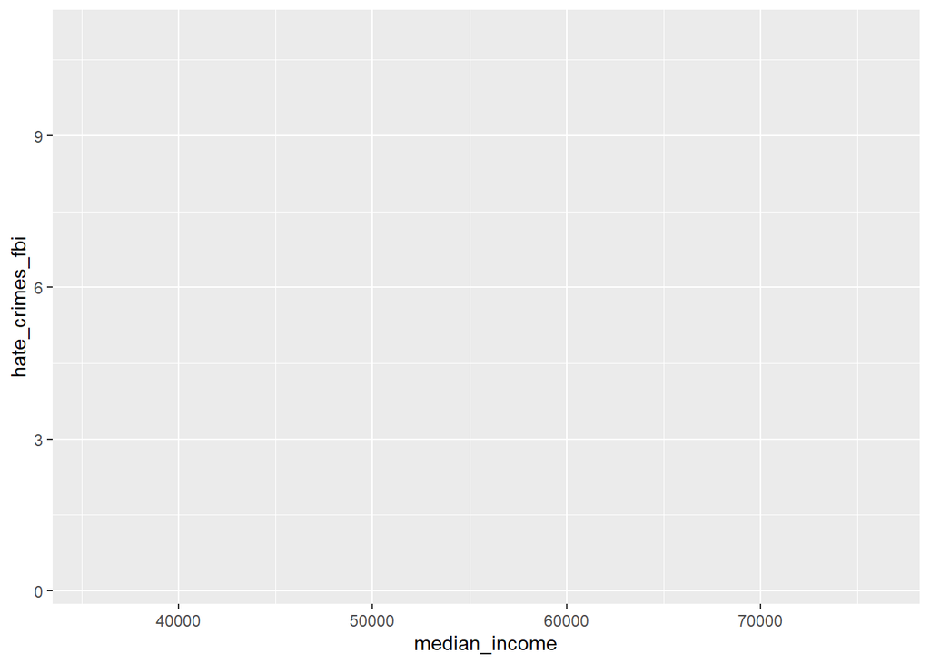

```r
ggplot(hate_crimes, aes(x=median_income, y=hate_crimes_fbi))
```

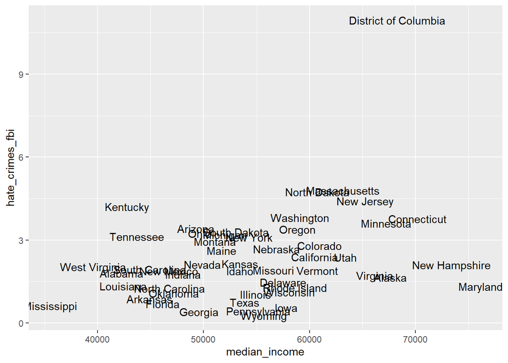

```r
ggplot(hate_crimes, aes(x=median_income, y=hate_crimes_fbi)) +
  geom_text(aes(label=state))
```

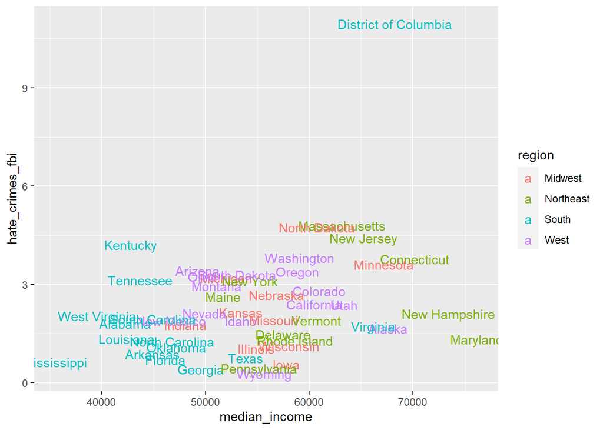

```r
ggplot(hate_crimes, aes(x=median_income, y=hate_crimes_fbi)) +
  geom_text(aes(label=state, color=region))
```

## Measuring income inequality

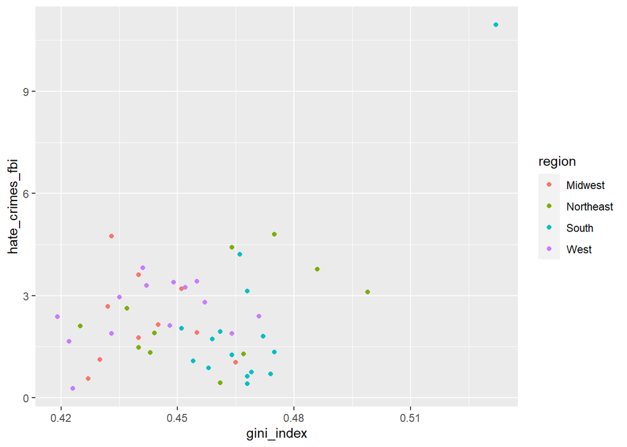

```r
ggplot(hate_crimes, aes(x=gini_index, y=hate_crimes_fbi)) +
  geom_point(aes(color=region))
```

Does source matter?

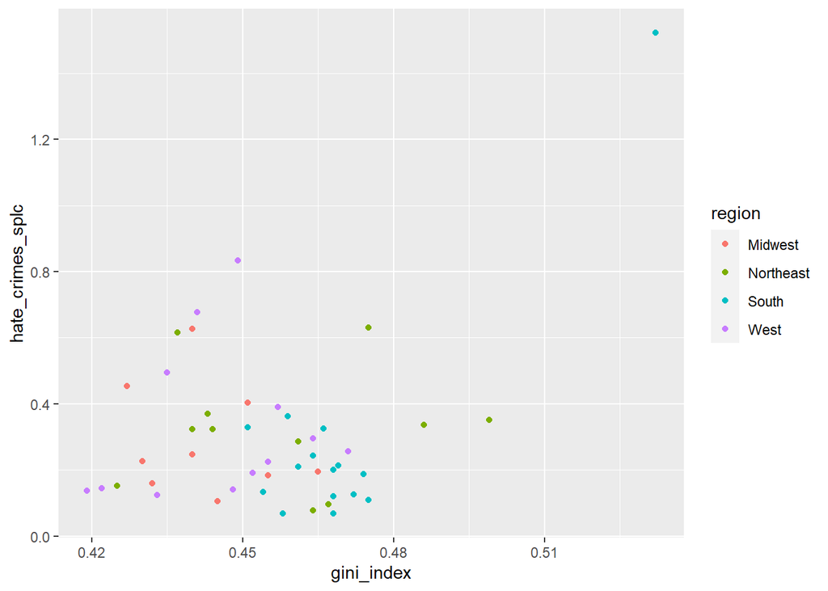

```r
ggplot(hate_crimes, aes(x=gini_index, y=hate_crimes_splc)) +
  geom_point(aes(color=region))
```

## Adding plot options

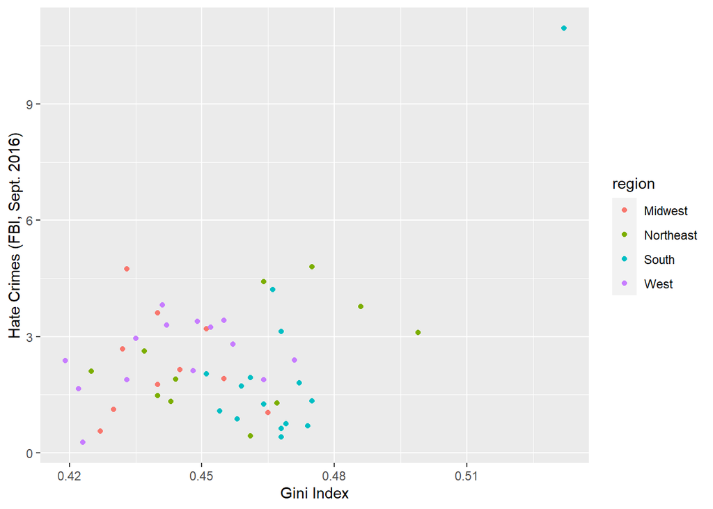

```r
ggplot(hate_crimes, aes(x=gini_index, y=hate_crimes_fbi)) +
  geom_point(aes(color=region)) +
  xlab('Gini Index') +
  ylab('Hate Crimes (FBI, Sept. 2016)')
```

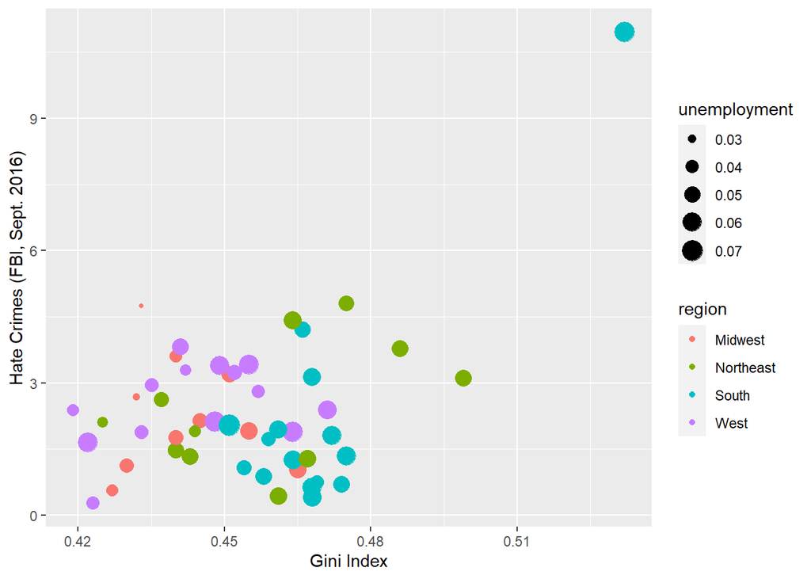

```r
ggplot(hate_crimes, aes(x=gini_index, y=hate_crimes_fbi)) +
  geom_point(aes(color=region, size=unemployment)) +
  xlab('Gini Index') +
  ylab('Hate Crimes (FBI, Sept. 2016)')
```

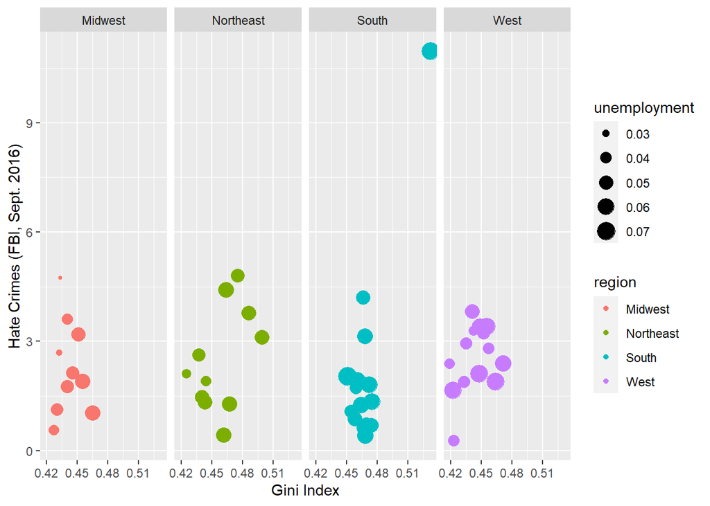

```r
ggplot(hate_crimes, aes(x=gini_index, y=hate_crimes_fbi)) +
  geom_point(aes(color=region, size=unemployment)) +
  xlab('Gini Index') +
  ylab('Hate Crimes (FBI, Sept. 2016)') +
  facet_wrap(~region, nrow=1)
```

## Weather patterns

The data set `Weather` contains data on weather-related variables for several world cities.

```r
#install.packages(mosaicData)
library(mosaicData)
data(Weather)
glimpse(Weather)
```

```
## Rows: 3,655
## Columns: 25
## $ city          <chr> "Auckland", "Auckland", "Auckland", "Auckland", "Auck...
## $ date          <date> 2016-01-01, 2016-01-02, 2016-01-03, 2016-01-04, 2016...
## $ year          <dbl> 2016, 2016, 2016, 2016, 2016, 2016, 2016, 2016, 2016,...
## $ month         <int> 1, 1, 1, 1, 1, 1, 1, 1, 1, 1, 1, 1, 1, 1, 1, 1, 1, 1,...
## $ day           <dbl> 1, 2, 3, 4, 5, 6, 7, 8, 9, 10, 11, 12, 13, 14, 15, 16...
## $ high_temp     <dbl> 68, 68, 77, 73, 69, 69, 71, 77, 69, 71, 75, 69, 71, 7...
## $ avg_temp      <dbl> 65, 66, 72, 66, 62, 63, 66, 70, 66, 66, 67, 66, 66, 6...
## $ low_temp      <dbl> 62, 64, 66, 60, 55, 57, 60, 64, 64, 62, 59, 62, 62, 6...
## $ high_dewpt    <dbl> 64, 64, 70, 66, 55, 54, 59, 72, 68, 63, 61, 66, 61, 6...
## $ avg_dewpt     <dbl> 60, 63, 67, 60, 52, 51, 54, 67, 61, 58, 58, 62, 57, 6...
## $ low_dewpt     <dbl> 55, 61, 64, 54, 48, 46, 50, 59, 55, 55, 54, 59, 54, 5...
## $ high_humidity <dbl> 100, 100, 100, 100, 82, 88, 83, 100, 100, 88, 94, 100...
## $ avg_humidity  <dbl> 82, 94, 91, 76, 69, 65, 65, 92, 81, 76, 72, 87, 73, 8...
## $ low_humidity  <dbl> 68, 88, 74, 53, 56, 46, 53, 83, 64, 64, 53, 78, 64, 6...
## $ high_hg       <dbl> 30.15, 30.04, 29.80, 30.12, 30.21, 30.24, 30.24, 30.0...
## $ avg_hg        <dbl> 30.09, 29.90, 29.73, 29.90, 30.14, 30.22, 30.13, 29.7...
## $ low_hg        <dbl> 30.01, 29.80, 29.68, 29.77, 30.09, 30.18, 30.04, 29.6...
## $ high_vis      <dbl> 6, 6, 6, 6, 6, 6, 6, 6, 6, 6, 6, 6, 6, 6, 6, 6, 6, 6,...
## $ avg_vis       <dbl> 6, 5, 6, 6, 6, 6, 6, 6, 6, 6, 6, 6, 6, 6, 6, 6, 6, 6,...
## $ low_vis       <dbl> 4, 1, 1, 6, 6, 6, 6, 2, 4, 6, 6, 3, 6, 6, 6, 6, 6, 2,...
## $ high_wind     <dbl> 21, 33, 18, 15, 13, 17, 22, 21, 18, 20, 17, 16, 18, 1...
## $ avg_wind      <dbl> 15, 21, 12, 10, 7, 8, 12, 14, 11, 15, 10, 8, 13, 9, 7...
## $ low_wind      <dbl> 28, 46, NA, NA, NA, 28, 25, 28, 29, NA, 26, NA, NA, N...
## $ precip        <chr> "0", "0", "0", "0", "0", "0", "0", "0", "0", "0", "0"...
## $ events        <chr> "Rain", "Rain", "Rain", "Rain", NA, NA, "Rain", "Rain...
```

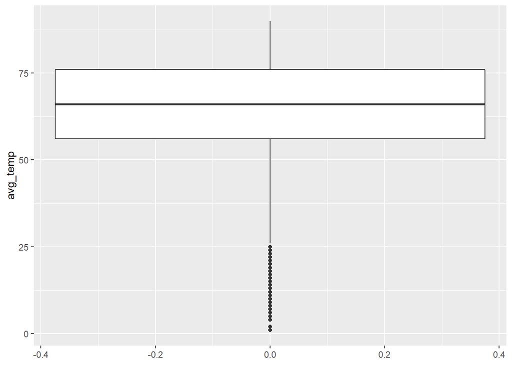

```r
ggplot(Weather, aes(y=avg_temp)) +
  geom_boxplot()
```

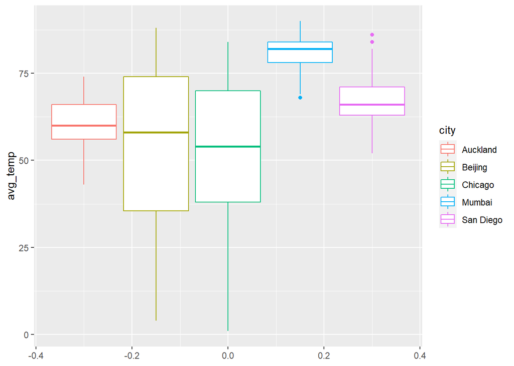

```r
ggplot(Weather, aes(y=avg_temp, group=city)) +
  geom_boxplot(aes(color=city))
```

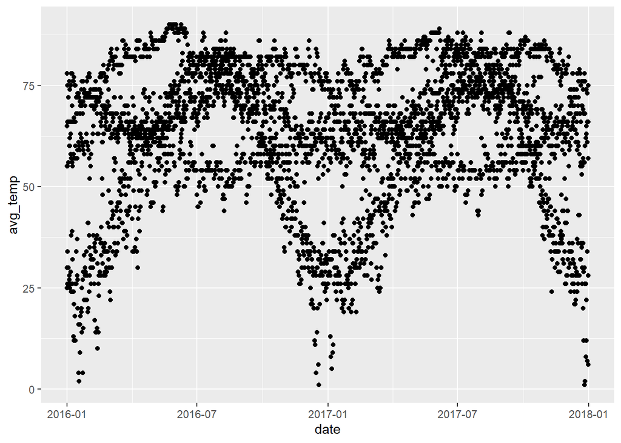

```r
ggplot(Weather, aes(x=date, y=avg_temp)) +
  geom_point()
```

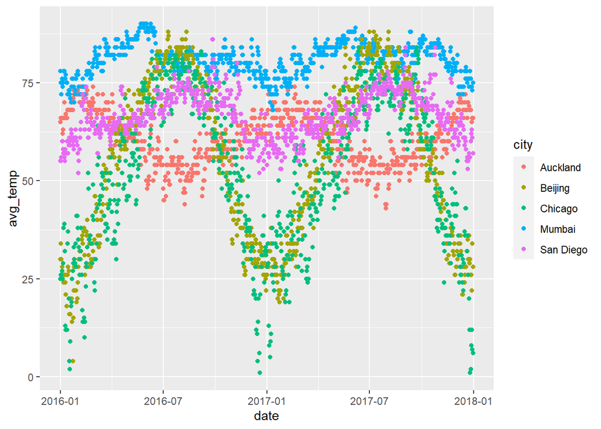

```r
ggplot(Weather, aes(x=date, y=avg_temp)) +
  geom_point(aes(color=city))
```

### Weather patterns in Chicago

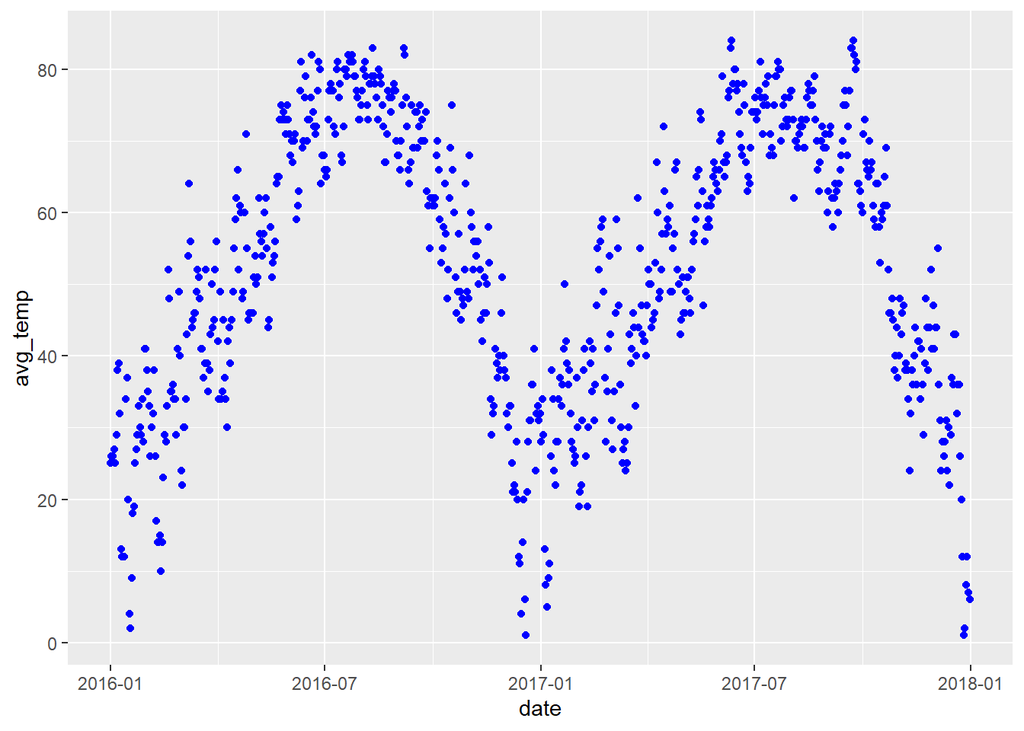

```r
Chicago <- Weather %>% filter(city=='Chicago')
ggplot(Chicago, aes(x=date, y=avg_temp)) +
  geom_point(col='blue')
```

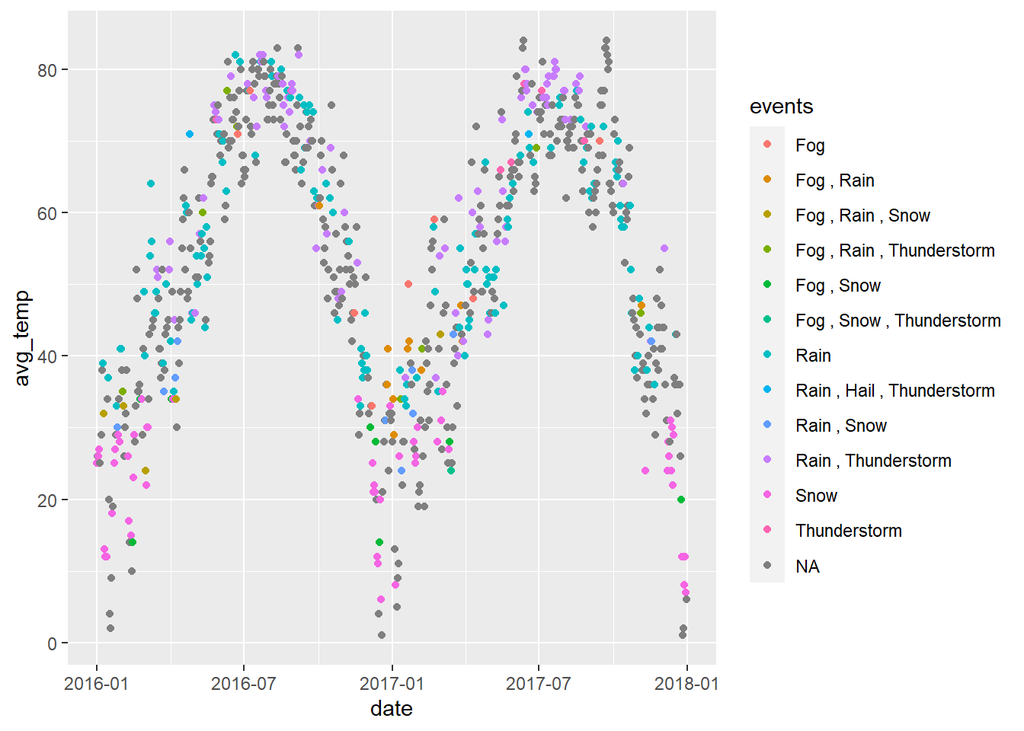

```r
ggplot(Chicago, aes(x=date, y=avg_temp)) +
  geom_point(aes(color=events))
```

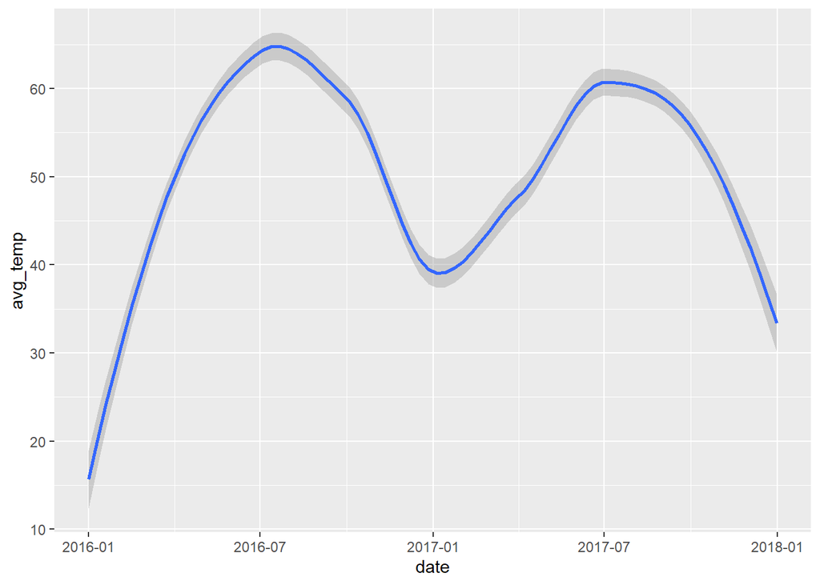

```r
ggplot(Chicago, aes(x=date, y=avg_temp)) +
  geom_smooth()
```

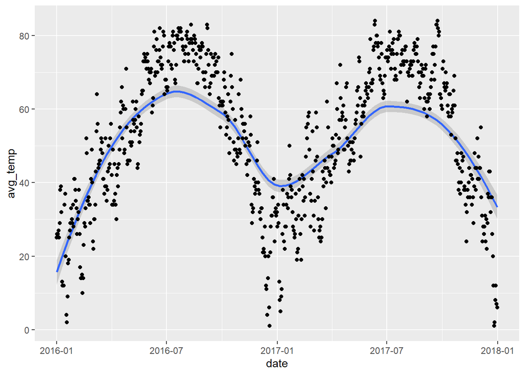

```r
ggplot(Chicago, aes(x=date, y=avg_temp)) +
  geom_smooth() +
  geom_point()
```

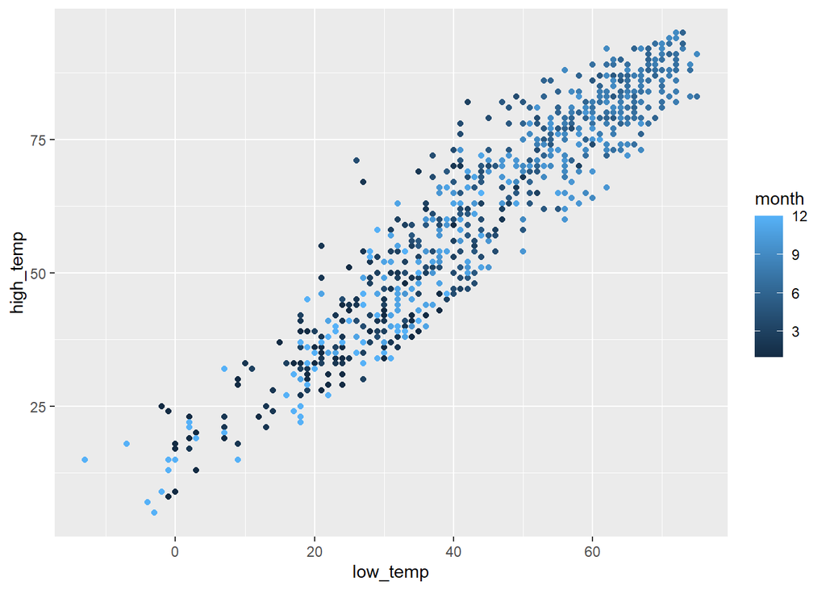

```r
ggplot(Chicago, aes(x=low_temp, y=high_temp)) +
  geom_point(aes(color=month))
```

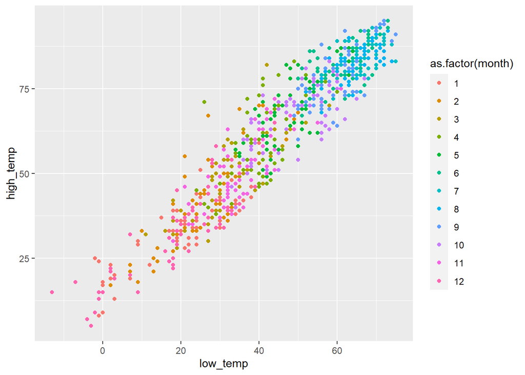

```r
ggplot(Chicago, aes(x=low_temp, y=high_temp)) +
  geom_point(aes(color=as.factor(month)))
```

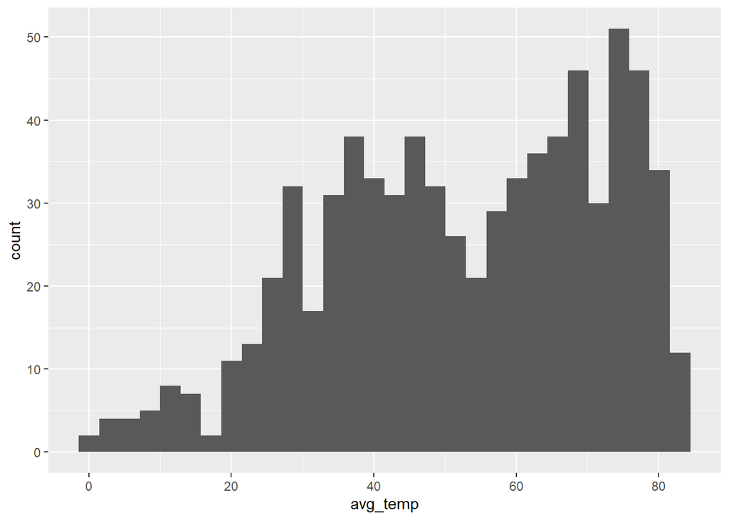

```r
ggplot(Chicago, aes(x=avg_temp)) +
  geom_histogram()
```

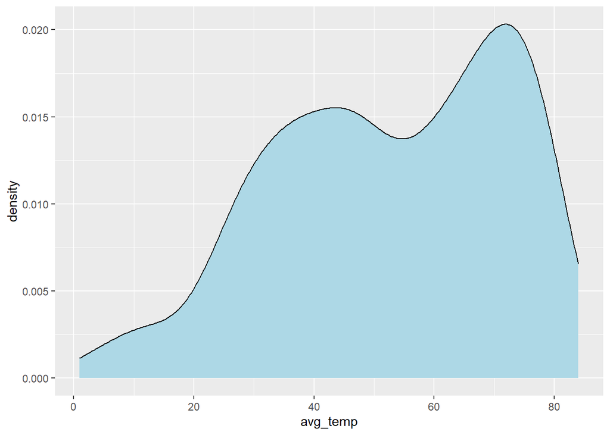

```r
ggplot(Chicago, aes(x=avg_temp)) +
  geom_density(fill='lightblue')
```

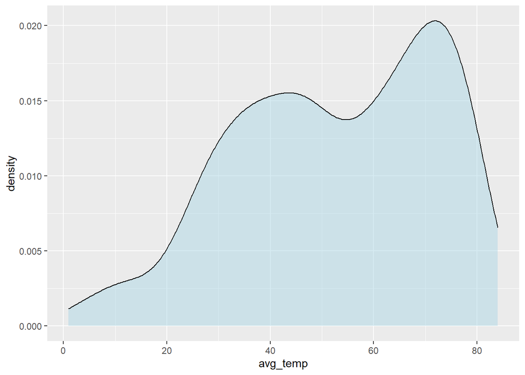

```r
ggplot(Chicago, aes(x=avg_temp)) +
  geom_density(fill='lightblue', alpha=0.5)
```

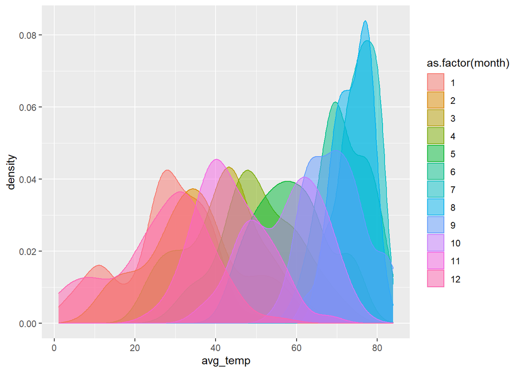

```r
ggplot(Chicago, aes(x=avg_temp, group=month)) +
  geom_density(aes(color=as.factor(month), fill=as.factor(month)), alpha=0.5)
```

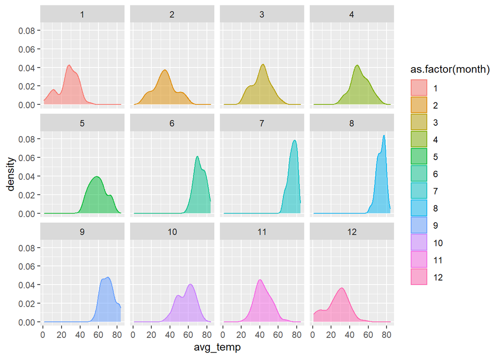

```r
ggplot(Chicago, aes(x=avg_temp, group=month)) +
  geom_density(aes(color=as.factor(month), fill=as.factor(month)), alpha=0.5) +
  facet_wrap(~month, nrow=3)
```

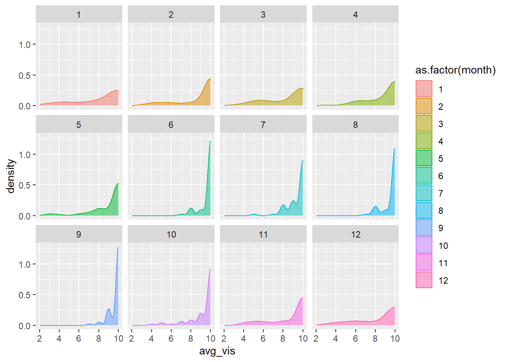

```r
ggplot(Chicago, aes(x=avg_vis, group=month)) +
  geom_density(aes(color=as.factor(month), fill=as.factor(month)), alpha=0.5) +
  facet_wrap(~month, nrow=3)
```

## Weather events

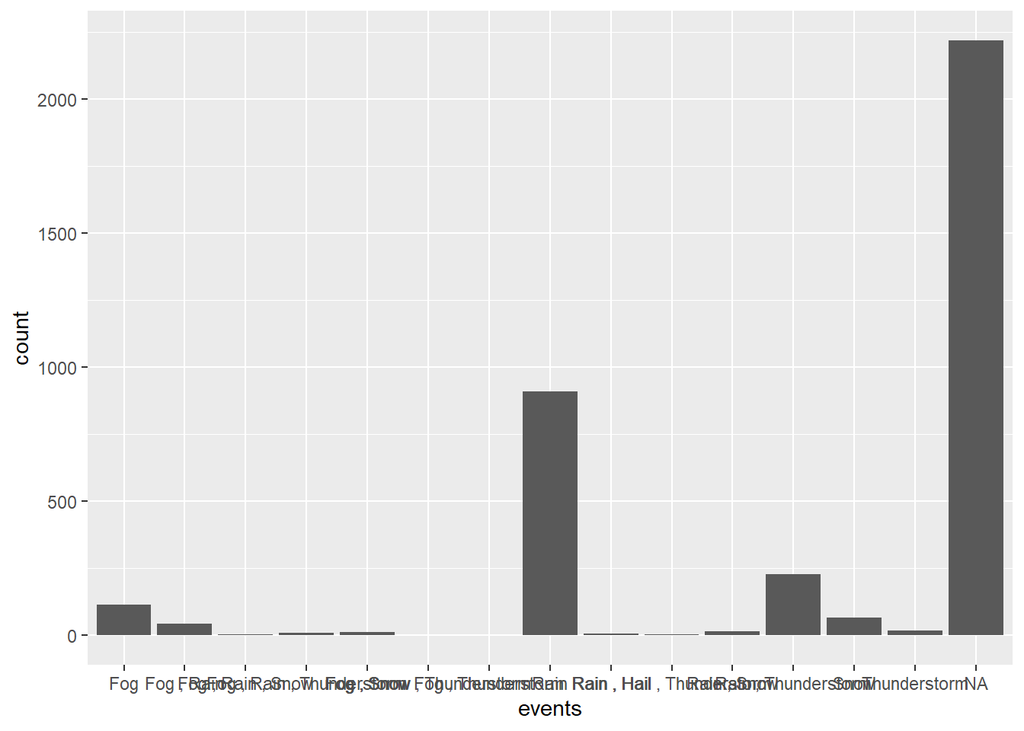

```r
ggplot(Weather, aes(x=events)) +
  geom_bar()
```

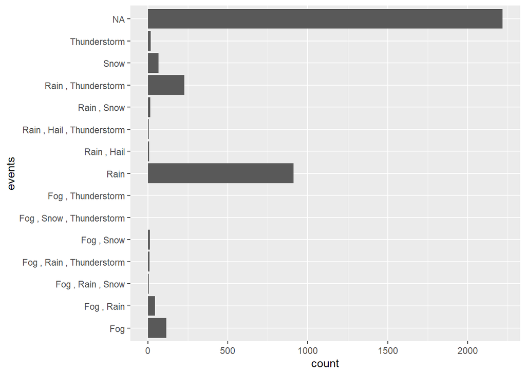

```r
ggplot(Weather, aes(x=events)) +
  geom_bar() +
  coord_flip()
```

### Weather events in Chicago

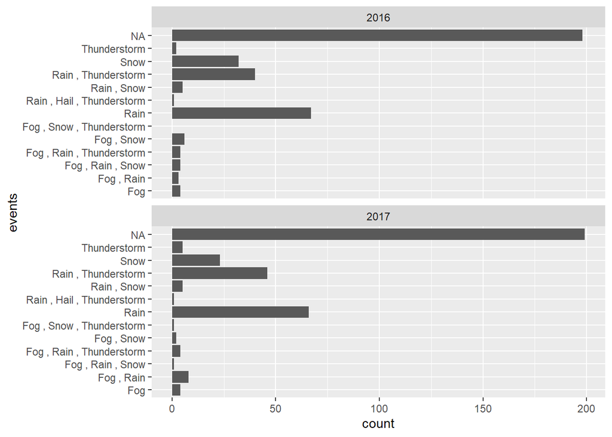

```r
ggplot(Chicago, aes(x=events)) +
  geom_bar() +
  coord_flip() +
  facet_wrap(~year, nrow=2)
```

## Mutate Command

We’re going to cover one data wrangling command here, and its the ‘Mutate’ command. The mutate function is used to add columns to a dataframe (and not, as the same seems to suggest, change existing columns). As an example, we are going to add a column to the Weather dataset that records the gap between the high temperature and the low temperature for each row.

```r
weather_gap<-Weather%>%
  mutate(gap =high_temp-low_temp)
glimpse(weather_gap)
```

```
## Rows: 3,655
## Columns: 26
## $ city          <chr> "Auckland", "Auckland", "Auckland", "Auckland", "Auck...
## $ date          <date> 2016-01-01, 2016-01-02, 2016-01-03, 2016-01-04, 2016...
## $ year          <dbl> 2016, 2016, 2016, 2016, 2016, 2016, 2016, 2016, 2016,...
## $ month         <int> 1, 1, 1, 1, 1, 1, 1, 1, 1, 1, 1, 1, 1, 1, 1, 1, 1, 1,...
## $ day           <dbl> 1, 2, 3, 4, 5, 6, 7, 8, 9, 10, 11, 12, 13, 14, 15, 16...
## $ high_temp     <dbl> 68, 68, 77, 73, 69, 69, 71, 77, 69, 71, 75, 69, 71, 7...
## $ avg_temp      <dbl> 65, 66, 72, 66, 62, 63, 66, 70, 66, 66, 67, 66, 66, 6...
## $ low_temp      <dbl> 62, 64, 66, 60, 55, 57, 60, 64, 64, 62, 59, 62, 62, 6...
## $ high_dewpt    <dbl> 64, 64, 70, 66, 55, 54, 59, 72, 68, 63, 61, 66, 61, 6...
## $ avg_dewpt     <dbl> 60, 63, 67, 60, 52, 51, 54, 67, 61, 58, 58, 62, 57, 6...
## $ low_dewpt     <dbl> 55, 61, 64, 54, 48, 46, 50, 59, 55, 55, 54, 59, 54, 5...
## $ high_humidity <dbl> 100, 100, 100, 100, 82, 88, 83, 100, 100, 88, 94, 100...
## $ avg_humidity  <dbl> 82, 94, 91, 76, 69, 65, 65, 92, 81, 76, 72, 87, 73, 8...
## $ low_humidity  <dbl> 68, 88, 74, 53, 56, 46, 53, 83, 64, 64, 53, 78, 64, 6...
## $ high_hg       <dbl> 30.15, 30.04, 29.80, 30.12, 30.21, 30.24, 30.24, 30.0...
## $ avg_hg        <dbl> 30.09, 29.90, 29.73, 29.90, 30.14, 30.22, 30.13, 29.7...
## $ low_hg        <dbl> 30.01, 29.80, 29.68, 29.77, 30.09, 30.18, 30.04, 29.6...
## $ high_vis      <dbl> 6, 6, 6, 6, 6, 6, 6, 6, 6, 6, 6, 6, 6, 6, 6, 6, 6, 6,...
## $ avg_vis       <dbl> 6, 5, 6, 6, 6, 6, 6, 6, 6, 6, 6, 6, 6, 6, 6, 6, 6, 6,...
## $ low_vis       <dbl> 4, 1, 1, 6, 6, 6, 6, 2, 4, 6, 6, 3, 6, 6, 6, 6, 6, 2,...
## $ high_wind     <dbl> 21, 33, 18, 15, 13, 17, 22, 21, 18, 20, 17, 16, 18, 1...
## $ avg_wind      <dbl> 15, 21, 12, 10, 7, 8, 12, 14, 11, 15, 10, 8, 13, 9, 7...
## $ low_wind      <dbl> 28, 46, NA, NA, NA, 28, 25, 28, 29, NA, 26, NA, NA, N...
## $ precip        <chr> "0", "0", "0", "0", "0", "0", "0", "0", "0", "0", "0"...
## $ events        <chr> "Rain", "Rain", "Rain", "Rain", NA, NA, "Rain", "Rain...
## $ gap           <dbl> 6, 4, 11, 13, 14, 12, 11, 13, 5, 9, 16, 7, 9, 13, 13,...
```

Reflection Questions:

1. With 1 being too slow and 5 being too fast, how was the speed of the video? 3, the video was a good pace
2. With 1 being too basic and 5 being too advanced, how was the level of the video? 4 it was hard to comprehend initially but I got it after I talked to the prof and watched it again.
3. Are there any topics you specifically want to address during the class meeting? Nope
4. Any additonal thoughts/comments on the notes: Now that I’m not overthinking them, it’s definately easier